# Classification of quality of exercise using Random Forest, Gradient Boosting and Linear Discriminant Model

## Analysis

#### Correlation

Checking independence of predictors

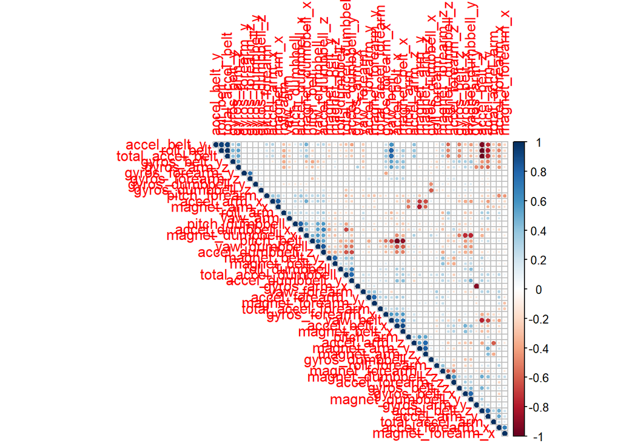

```r
res<-cor(training_red_final2[,-53])
corrplot(res, type = "upper", order = "hclust")
```

From the corrplot we can say that predictors like acc_belt_z is highly -vely correlated to acc_belt_y and 2 others and hence multi-collinearity exists. Based on manual selection, we will be removing following columns because of their correlation with other predictors (Left-COlumn name : Righ-Their position in training_red_final2 table)

```r
#---accel_belt_z 10
#---accel_arm_y 22
#---yaw_belt 3
#---magnet_belt_x 11
training_red_final3<-training_red_final2[,-c(10,22,3,11)]
testing_red_final3<-testing_red_final[,-c(10,22,3,11)]
```

## Final Model

Creating training and testing dataset within original training dataset to look at out of sample error rates from 3 different models: Random forest, gradient boost model and linear discriminant analysis

```r
train_obj<-createDataPartition(training_red_final3$classe, p = 0.6, list = FALSE)
intrain<-training_red_final3[train_obj,]
intest<-training_red_final3[-train_obj,]

system.time(mod_rf<-train(classe ~ .,data = intrain,method = "rf"))
system.time(mod_gbm<-train(classe ~ .,data = intrain,method = "gbm"))
system.time(mod_lda<-train(classe ~ .,data = intrain,method = "lda"))


pred_rf<-predict(mod_rf,intest)
confusionMatrix(pred_rf,intest$classe)
#Accuracy : 0.9874

pred_gbm<-predict(mod_gbm,intest)
confusionMatrix(pred_gbm,intest$classe)
#Accuracy : 0.9517

pred_lda<-predict(mod_lda,intest)
confusionMatrix(pred_lda,intest$classe)
#Accuracy : 0.6868
```

Since random forest gave us the best out of sample accuracy (RF = 98%, GBM = 95%, LDA = 68%), we will be using the above created random forest model on final testing dataset.

```r
pred_testing<-predict(mod_rf,testing_red_final3)
pred_testing
```

Following were the predictions, which were found to be 100% true when checked against provided answers.

| Testing Observation | Predictions |
| --- | --- |
| 1 | B |
| 2 | A |
| 3 | B |
| 4 | A |
| 5 | A |
| 6 | E |
| 7 | D |
| 8 | B |
| 9 | A |
| 10 | A |
| 11 | B |
| 12 | C |
| 13 | B |
| 14 | A |
| 15 | E |
| 16 | E |
| 17 | A |
| 18 | B |
| 19 | B |
| 20 | B |

```r
varImp(mod_rf)
```

[output not shown]

## Source of the data

The training data for this project are available here: https://d396qusza40orc.cloudfront.net/predmachlearn/pml-training.csv

The test data are available here: https://d396qusza40orc.cloudfront.net/predmachlearn/pml-testing.csv

The data for this project come from this source: http://groupware.les.inf.puc-rio.br/har

The data has been published here:

*Velloso, E.; Bulling, A.; Gellersen, H.; Ugulino, W.; Fuks, H. Qualitative Activity Recognition of Weight Lifting Exercises. Proceedings of 4th International Conference in Cooperation with SIGCHI (Augmented Human ’13). Stuttgart, Germany: ACM SIGCHI, 2013.*